# Chapter II - Sampling design comparison

# 3 Results

A total of 285 BRUV samples were collected, including 47 clustered and 238 spatially balanced samples (Table @ref(tab:n_samples_table)). Habitat was sampled differently between sampling designs, with 92.1% of all clustered habitat sampling points being seagrass, 5.7% being sand, and 2.1% being reef. The spatially balanced design habitat points were seagrass 62.8% of the time, sand 13.6% of the time, and reef 23.6% of the time. A total of 183 species were detected in samples, including 56 species identified to the Genus or Family level and 127 species identified to the species level. Certain species that were difficult to identify or differentiate with certainty were grouped together to form a complex, and are considered as one species.

## 3.1 Effect of sampling design on the detection of community composition differences around a NTZ

We observed a difference in the fish community composition between the clustered and spatially balanced sampling designs (see @ref(fig:composition_plot)) and @(tab:manyglm_output_table)). Clustered sampling communities were broadly separated into two groups, with the shoreward samples being very similar to each other (PC1 > 0 and PC2 < 0.1 on Figure @ref(fig:composition_plot), see Figure @ref(fig:real_BRUV_location)) and seaward samples being similar to each other (PC1 < 0 on Figure @ref(fig:composition_plot), see @ref(real_BRUV_location)), but distinct from the shoreward samples. Spatially balanced samples’ community composition did not display this grouping characteristic as intensely. The total abundance increased in the NTZ for both designs, although the clustered design found a larger increase inside the NTZ (clustered: +34%, spatially balanced: +24%). Log skew was slightly higher in the NTZ for both designs (clustered: +1%, spatially balanced: +12%), and log-μ in the NTZ was slightly higher for preferential designs, and slightly lower for spatially balanced designs (clustered: +6%, spatially balanced: -4%, Figure @ref(fig:composition_plot))

| Variable | Res.Df | Df.diff | Dev | Pr(>Dev) |  |
| --- | --- | --- | --- | --- | --- |
| (Intercept) | 98 |  |  | NA |  |
| Sampling Design | 97 | 1 | 375.1 | 0.001 | *** |
| Status | 96 | 1 | 163.3 | 0.116 |  |
| Sampling Design:Status | 95 | 1 | 85.1 | 0.232 |  |

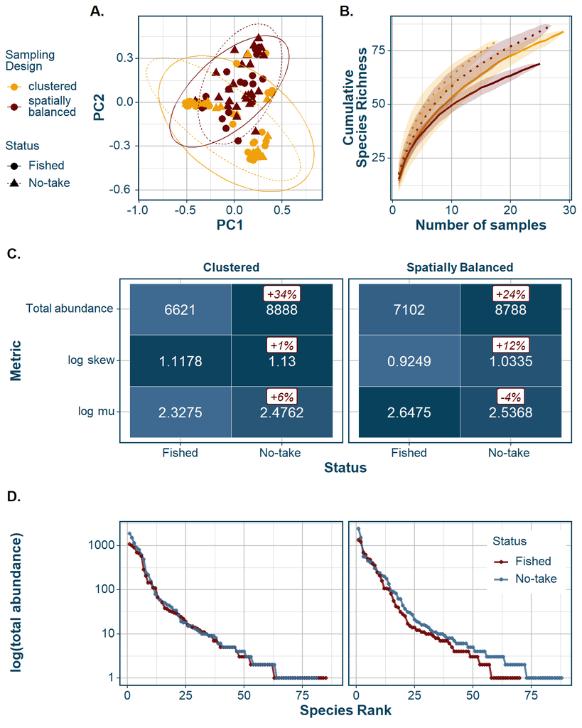

## 3.2 Effect of sampling design on the detection of NTZ increases in single species abundance.

Abundance inside and outside the NTZ was detected differently depending on the sampling design, and depending on the species:

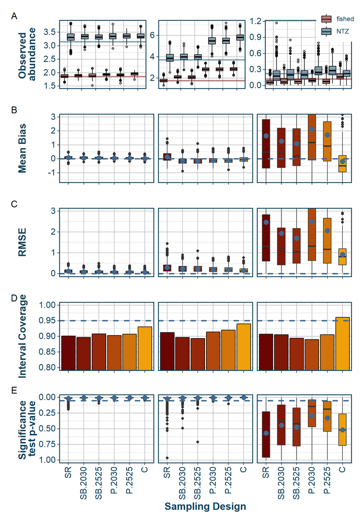